# R Notebook

```r
library(rpart)
library(caret)
library(dplyr)
```

```r
eleicoes <- read.csv("train.csv", encoding = "UTF-8")
```

## 1. Há desbalanceamento das classes (isto é, uma classe tem muito mais instâncias que outra)? Em que proporção? Quais efeitos colaterais o desbalanceamento de classes pode causar no classificador?

Para responder esta questão iremos plotar a diferença entre as duas classes: eleito e não eleito.

```r
df_classes <- eleicoes %>% count(situacao_final)
df_classes
```

| situacao_final | n |
| --- | --- |
| eleito | 416 |
| nao_eleito | 3719 |

Para ilustrar melhor, plotamos o gráfico com a proporção:

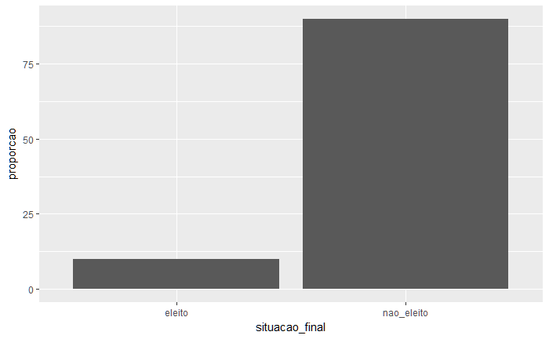

```r
proporcao <- (df_classes$n/sum(df_classes$n) * 100)
ggplot(df_classes, aes(x = situacao_final, y = proporcao), options(scipen=5)) +
    geom_bar(stat = "identity")
```

Foi percebido que a classe nao_eleito (não eleito) possui muito mais instâncias que a classe eleito. eleito possui 416 instâncias e nao_eleito possui 3719 instâncias, com proporção de 10,1% e 89,9%. Ao treinar um modelo futuro ele tende a ficar enviesado visto que a diferença entre nao_eleito e eleito é visivelmente grande.

## 2. Treine: um modelo de regressão logística, uma árvore de decisão e um modelo de adaboost. Tune esses modelos usando validação cruzada e controle overfitting se necessário, considerando as particularidades de cada modelo.

Podemos escolher algumas variáveis com as quais queremos trabalhar:

```r
filtra_dados <- eleicoes %>% select(total_receita, total_despesa, descricao_cor_raca, estado_civil, grau, situacao_final)
```

```r
# Separa os dados em treino e teste
dataPartition <- createDataPartition(y = filtra_dados$situacao_final , p=0.70, list=FALSE)
treino <- filtra_dados[ dataPartition, ]
teste <- filtra_dados[ -dataPartition, ]
```

Já que vimos na questão anterior que as classes estão desbalanceadas, é importante balanceá-las para depois treinar o modelo. Escolhemos usar a ideia de under-sampling.

```r
ctrl <- trainControl(method = "repeatedcv",
                     #number = 10,
                     repeats = 5,
                     verboseIter = FALSE,
                     sampling = "down")
formula = as.formula(situacao_final ~ .)
```

### Regressão logística:

```r
reg_log1 <- train(formula,
                  data = treino,
                  method="glm",
                  trControl = ctrl,
                  family="binomial",      # se a variável for binária
                  na.action = na.omit)
reg_log1
```

```
Generalized Linear Model

2896 samples
   5 predictor
   2 classes: 'eleito', 'nao_eleito'

No pre-processing
Resampling: Cross-Validated (10 fold, repeated 5 times)
Summary of sample sizes: 2607, 2606, 2606, 2606, 2607, 2607, ...
Addtional sampling using down-sampling

Resampling results:

  Accuracy   Kappa
  0.9254745  0.6559179
```

### Árvore de decisão:

```r
arvore <- train(formula,
                 data = treino,
                 method = "rpart",
                 trControl = ctrl,
                 minsplit=20,
                 cp=0.01,  # parâmetro de complexidade
                 maxdepth=20)
arvore
```

```
CART

2896 samples
   5 predictor
   2 classes: 'eleito', 'nao_eleito'

No pre-processing
Resampling: Cross-Validated (10 fold, repeated 5 times)
Summary of sample sizes: 2607, 2606, 2607, 2606, 2606, 2606, ...
Addtional sampling using down-sampling

Resampling results across tuning parameters:

  cp          Accuracy   Kappa
  0.01484018  0.8986208  0.6047884
  0.02397260  0.8986208  0.6047884
  0.33561644  0.8986208  0.6047884

Accuracy was used to select the optimal model using  the largest value.
The final value used for the model was cp = 0.3356164.
```

### Adaboost:

```r
boost <- train(formula,
                data=treino,
                trControl = ctrl,
                method = "adaboost")
boost
```

[output not shown]

## 3. Reporte acurácia, precision, recall e f-measure no treino e validação. Como você avalia os resultados? Justifique sua resposta.

Acurácia = (TP + TN)/(TP + TN + FP + FN) *Nos diz a proporção de observações corretamente classificadas.*

Precision = TP / (TP + FP) *Diz respeito a quantas das observaçoes preditas como positivas são realmente positivas*

Recall = TP / (TP + FN) *Diz respeito a quantas das observaçoes positivas foram corretamente classificadas*

F-Measure = 2 x (Recall x Precision) / (Recall + Precision)

### Regressão logística no treino:

```r
treino$predicao_log <- predict(reg_log1, treino)
```

[output not shown]

```r
TP <- treino %>% filter(situacao_final == "eleito", predicao_log == "eleito") %>% nrow()
TN <- treino %>% filter(situacao_final == "nao_eleito" , predicao_log == "nao_eleito" ) %>% nrow()
FP <- treino %>% filter(situacao_final == "nao_eleito" , predicao_log == "eleito") %>% nrow()
FN <- treino %>% filter(situacao_final == "eleito", predicao_log == "nao_eleito" ) %>% nrow()
accuracy <- (TP + TN)/(TP + TN + FP + FN)
precision <- TP / (TP + FP)
recall <- TP / (TP + FN)
f_measure <- 2*(recall * precision) / (recall + precision)
accuracy
```

```
[1] 0.9267956
```

```r
precision
```

```
[1] 0.5938967
```

```r
recall
```

```
[1] 0.8664384
```

```r
f_measure
```

```
[1] 0.7047354
```

### Regressão logística no teste:

```r
teste$predicao_log <- predict(reg_log1, teste)
```

[output not shown]

```r
TP <- teste %>% filter(situacao_final == "eleito", predicao_log == "eleito") %>% nrow()
TN <- teste %>% filter(situacao_final == "nao_eleito" , predicao_log == "nao_eleito" ) %>% nrow()
FP <- teste %>% filter(situacao_final == "nao_eleito" , predicao_log == "eleito") %>% nrow()
FN <- teste %>% filter(situacao_final == "eleito", predicao_log == "nao_eleito" ) %>% nrow()
accuracy <- (TP + TN)/(TP + TN + FP + FN)
precision <- TP / (TP + FP)
recall <- TP / (TP + FN)
f_measure <- 2*(recall * precision) / (recall + precision)
accuracy
```

```
[1] 0.9233253
```

```r
precision
```

```
[1] 0.5819209
```

```r
recall
```

```
[1] 0.8306452
```

```r
f_measure
```

```
[1] 0.6843854
```

Os valores de acurácia, precisão, recall e f-measure são maiores na partição de treino do que na partição de teste.

### Árvore de decisão no treino:

```r
treino$predicao_arvore <- predict(arvore, treino)
TP <- treino %>% filter(situacao_final == "eleito", predicao_arvore == "eleito") %>% nrow()
TN <- treino %>% filter(situacao_final == "nao_eleito" , predicao_arvore == "nao_eleito" ) %>% nrow()
FP <- treino %>% filter(situacao_final == "nao_eleito" , predicao_arvore == "eleito") %>% nrow()
FN <- treino %>% filter(situacao_final == "eleito", predicao_arvore == "nao_eleito" ) %>% nrow()
accuracy <- (TP + TN)/(TP + TN + FP + FN)
precision <- TP / (TP + FP)
recall <- TP / (TP + FN)
f_measure <- 2*(recall * precision) / (recall + precision)
accuracy
```

```
[1] 0.905732
```

```r
precision
```

```
[1] 0.5176909
```

```r
recall
```

```
[1] 0.9520548
```

```r
f_measure
```

```
[1] 0.6706876
```

### Árvore de decisão no teste:

```r
teste$predicao_arvore <- predict(arvore, teste)
TP <- teste %>% filter(situacao_final == "eleito", predicao_arvore == "eleito") %>% nrow()
TN <- teste %>% filter(situacao_final == "nao_eleito" , predicao_arvore == "nao_eleito" ) %>% nrow()
FP <- teste %>% filter(situacao_final == "nao_eleito" , predicao_arvore == "eleito") %>% nrow()
FN <- teste %>% filter(situacao_final == "eleito", predicao_arvore == "nao_eleito" ) %>% nrow()
accuracy <- (TP + TN)/(TP + TN + FP + FN)
precision <- TP / (TP + FP)
recall <- TP / (TP + FN)
f_measure <- 2*(recall * precision) / (recall + precision)
accuracy
```

```
[1] 0.897498
```

```r
precision
```

```
[1] 0.4935065
```

```r
recall
```

```
[1] 0.9193548
```

```r
f_measure
```

```
[1] 0.6422535
```

Igualmente ao modelo de Regressão Logística, o modelo de Árvore de Decisão apresenta valores maiores na partição de treino.

### Adaboost no treino:

```r
treino$predicao_ada <- predict(boost, treino)
TP <- treino %>% filter(situacao_final == "eleito", predicao_ada == "eleito") %>% nrow()
TN <- treino %>% filter(situacao_final == "nao_eleito" , predicao_ada == "nao_eleito" ) %>% nrow()
FP <- treino %>% filter(situacao_final == "nao_eleito" , predicao_ada == "eleito") %>% nrow()
FN <- treino %>% filter(situacao_final == "eleito", predicao_ada == "nao_eleito" ) %>% nrow()
accuracy <- (TP + TN)/(TP + TN + FP + FN)
precision <- TP / (TP + FP)
recall <- TP / (TP + FN)
f_measure <- 2*(recall * precision) / (recall + precision)
accuracy
```

```
[1] 0.9167818
```

```r
precision
```

```
[1] 0.5478424
```

```r
recall
```

```
[1] 1
```

```r
f_measure
```

```
[1] 0.7078788
```

### Adaboost no teste:

```r
teste$predicao_ada <- predict(boost, teste)
TP <- teste %>% filter(situacao_final == "eleito", predicao_ada == "eleito") %>% nrow()
TN <- teste %>% filter(situacao_final == "nao_eleito" , predicao_ada == "nao_eleito" ) %>% nrow()
FP <- teste %>% filter(situacao_final == "nao_eleito" , predicao_ada == "eleito") %>% nrow()
FN <- teste %>% filter(situacao_final == "eleito", predicao_ada == "nao_eleito" ) %>% nrow()
accuracy <- (TP + TN)/(TP + TN + FP + FN)
precision <- TP / (TP + FP)
recall <- TP / (TP + FN)
f_measure <- 2*(recall * precision) / (recall + precision)
accuracy
```

```
[1] 0.889427
```

```r
precision
```

```
[1] 0.4718615
```

```r
recall
```

```
[1] 0.8790323
```

```r
f_measure
```

```
[1] 0.6140845
```

Como podemos notar, o modelo na partição treino apresenta acurácia, precisão, recall e f-measure maior que no teste, igualmente ao modelo de Árvore de Decisão e Regressão Logística.

```r
confusionMatrix(teste$predicao_log, teste$situacao_final)
```

```
Confusion Matrix and Statistics

            Reference
Prediction   eleito nao_eleito
  eleito        103         74
  nao_eleito     21       1041

               Accuracy : 0.9233
                 95% CI : (0.9071, 0.9375)
    No Information Rate : 0.8999
    P-Value [Acc > NIR] : 0.00266

                  Kappa : 0.6423
 Mcnemar's Test P-Value : 9.55e-08

            Sensitivity : 0.83065
            Specificity : 0.93363
         Pos Pred Value : 0.58192
         Neg Pred Value : 0.98023
             Prevalence : 0.10008
         Detection Rate : 0.08313
   Detection Prevalence : 0.14286
      Balanced Accuracy : 0.88214

       'Positive' Class : eleito
```

```r
confusionMatrix(teste$predicao_arvore, teste$situacao_final)
```

```
Confusion Matrix and Statistics

            Reference
Prediction   eleito nao_eleito
  eleito        114        117
  nao_eleito     10        998

               Accuracy : 0.8975
                 95% CI : (0.8793, 0.9138)
    No Information Rate : 0.8999
    P-Value [Acc > NIR] : 0.634

                  Kappa : 0.5887
 Mcnemar's Test P-Value : <2e-16

            Sensitivity : 0.91935
            Specificity : 0.89507
         Pos Pred Value : 0.49351
         Neg Pred Value : 0.99008
             Prevalence : 0.10008
         Detection Rate : 0.09201
   Detection Prevalence : 0.18644
      Balanced Accuracy : 0.90721

       'Positive' Class : eleito
```

```r
confusionMatrix(teste$predicao_ada, teste$situacao_final)
```

```
Confusion Matrix and Statistics

            Reference
Prediction   eleito nao_eleito
  eleito        109        122
  nao_eleito     15        993

               Accuracy : 0.8894
                 95% CI : (0.8706, 0.9064)
    No Information Rate : 0.8999
    P-Value [Acc > NIR] : 0.8981

                  Kappa : 0.5563
 Mcnemar's Test P-Value : <2e-16

            Sensitivity : 0.87903
            Specificity : 0.89058
         Pos Pred Value : 0.47186
         Neg Pred Value : 0.98512
             Prevalence : 0.10008
         Detection Rate : 0.08797
   Detection Prevalence : 0.18644
      Balanced Accuracy : 0.88481

       'Positive' Class : eleito
```

## 4. Interprete as saídas dos modelos. Quais atributos parecem ser mais importantes de acordo com cada modelo? Crie pelo menos um novo atributo que não está nos dados originais e estude o impacto desse atributo

```r
varImp(reg_log1)
```

```
glm variable importance

                                         Overall
`grauSUPERIOR COMPLETO`                 100.0000
`grauSUPERIOR INCOMPLETO`                78.1630
`estado_civilSOLTEIRO(A)`                55.9651
`grauENSINO MÉDIO COMPLETO`              48.2221
`grauENSINO FUNDAMENTAL INCOMPLETO`      41.2759
`estado_civilDIVORCIADO(A)`              39.2682
total_receita                            39.1599
`grauENSINO MÉDIO INCOMPLETO`            26.6803
`estado_civilSEPARADO(A) JUDICIALMENTE`  18.4527
`estado_civilVIÚVO(A)`                    7.8051
total_despesa                             0.2965
descricao_cor_racaPRETA                   0.2694
descricao_cor_racaPARDA                   0.2587
descricao_cor_racaBRANCA                  0.2578
`grauLÊ E ESCREVE`                        0.0000
```

De acordo com o modelo de regressão logística, o atributo mais importante é o grau de ensino.

```r
varImp(arvore)
```

```
rpart variable importance

                                        Overall
total_despesa                           100.000
total_receita                           100.000
grauSUPERIOR COMPLETO                    10.170
grauENSINO MÉDIO COMPLETO                 8.456
descricao_cor_racaBRANCA                  4.266
`grauENSINO MÉDIO INCOMPLETO`             0.000
`estado_civilDIVORCIADO(A)`               0.000
`grauSUPERIOR INCOMPLETO`                 0.000
`grauENSINO MÉDIO COMPLETO`               0.000
descricao_cor_racaPRETA                   0.000
`estado_civilVIÚVO(A)`                    0.000
`estado_civilSEPARADO(A) JUDICIALMENTE`   0.000
`grauSUPERIOR COMPLETO`                   0.000
`grauLÊ E ESCREVE`                        0.000
descricao_cor_racaINDÍGENA                0.000
`estado_civilSOLTEIRO(A)`                 0.000
`grauENSINO FUNDAMENTAL INCOMPLETO`       0.000
descricao_cor_racaPARDA                   0.000
```

De acordo com o método de árvore de decisão a receita e a despesas são importantes preditores da situação final, em seguida vem o grau de ensino.

```r
varImp(boost)
```

[output not shown]

Como visto no modelo de árvore de decisão, no Adaboost também observamos que receita e despesas são os mais importantes atributos.

## 5. Envie seus melhores modelos à competição do Kaggle. Sugestões abaixo:

### 1. Experimente outros modelos (e.g. SVM, RandomForests e GradientBoosting)

### 2. Crie novos atributos.

```r
kaggle_teste <- read.csv("test.csv", encoding="UTF-8")
```

```r
library(randomForest)
#ctrl2 <- trainControl(method = "repeatedcv",
#                     number = 10,
#                     repeats = 10,
#                     verboseIter = FALSE,
#                     sampling = "down")
#kaggle_reg_log <- train(situacao_final ~ .,
#                        data = filtra_dados,
#                        method="glm",
#                        trControl = ctrl2,
#                        family = "binomial",      # se a variável for binária
#                        na.action = na.omit)
kaggle_random_forest = randomForest(situacao_final ~ .,
                                    data = filtra_dados,
                                    family = "binomial",
                                    na.action = na.omit)
#summary(kaggle_reg_log)
#summary(kaggle_random_forest)
```

```r
predicao_kaggle <- predict(kaggle_random_forest, kaggle_teste)
kaggle_teste$prediction <- predicao_kaggle
kaggle_saida <- kaggle_teste %>% select(ID, prediction)
```

```r
write.csv(kaggle_saida, file = "kaggle_saida.csv", row.names = FALSE)
```

```r
filtra_dados$predicao_kaggle <- predict(kaggle_random_forest, filtra_dados)
TP <- filtra_dados %>% filter(situacao_final == "eleito", predicao_kaggle == "eleito") %>% nrow()
TN <- filtra_dados %>% filter(situacao_final == "nao_eleito" , predicao_kaggle == "nao_eleito" ) %>% nrow()
FP <- filtra_dados %>% filter(situacao_final == "nao_eleito" , predicao_kaggle == "eleito") %>% nrow()
FN <- filtra_dados %>% filter(situacao_final == "eleito", predicao_kaggle == "nao_eleito" ) %>% nrow()
accuracy <- (TP + TN)/(TP + TN + FP + FN)
precision <- TP / (TP + FP)
recall <- TP / (TP + FN)
accuracy
```

```
[1] 0.9883918
```

```r
precision
```

```
[1] 0.9867725
```

```r
recall
```

```
[1] 0.8966346
```